# 趋势拟合及预测

2020/5/28

## COVID-19预测预报非线性模型及其机理简介

本章节通过拟合患者比例和增长率的变化来分析疫情趋势，将复杂的外界影响因素视为患者数量增长的环境压力，以拟合生态增长曲线的方式解读2019-nCoV病毒的感染患者例数变化，分析国内外COVID-19疫情现状并预估发展趋势。

在时间序列里，有些变量的增长量最初比较小，随时间的增加逐渐增长而达到一个快速增长时期，而后增长速度趋缓，最终达到稳定的总增长量，这一过程若用曲线来表示，则是一种拉长的S形曲线。这种S形曲线因变量的增长特性的不同而呈现出多样性变化。通常传染病的累计病例遵循S形曲线增长。Logistic函数是一种常见的S形函数,在分析COVID-19疫情变化时，可以将患者看作在限定环境中数量增长的物种，实际中病毒的传播也存在人为管控或自然阻力，因此2019-nCoV病毒的感染者例数不会无限制的增长，在一定空间范围内应符合Logistic增长曲线。

## 数据说明

本章节选用2019年GDP前十的国家：美国、中国、日本、德国、印度、法国、英国、巴西、意大利和加拿大。对GDP-TOP10的国家自2019年12月31日至2020年5月24日COVID-19累计确诊病例进行拟合和预测，以及对GDP-TOP10的国家最终流行规模的预测值进行比较。同时，计算GDP-TOP10的国家自2019年12月31日至2020年5月24日每日确诊增长率数值辅助开展分析，预估GDP-TOP10的国家发展趋势。

## 方法说明

**(1) 曲线拟合方法**

曲线拟合（curve fitting）是指选择适当的曲线类型来拟合观测数据，并用拟合的曲线方程分析变量之间的关系。本章节将每日累计确诊病例数据制成散点图，采用单个变化量对时间的响应进行非线性回归拟合，取得拟合方程的系数，并绘制回归曲线。

结合\(S\)值、\(R^2\)值对拟合程度进行判断，其中\(S\)值描述了数据值与拟合值的距离，表示评估模型描述响应值的程度，其值越低，模型描述响应的程度越高；\(R^2\)值是度量拟合优度的统计量，介于\(0-1\)之间，也称拟合的确定系数，\(R^2\)越高可表示拟合优度越高。\(S\)值和\(R^2\)值表达式如下所示： \[S = \sum_{i=1}^{n}\qquad(y_i-\hat{y_i})\] \[R^2=1-\frac {SSE*(n-k)}{(var(y))*(n-1)}\]

**(2) Logistic 增长曲线**

本章节所采用的R包为**nlrwrb**包中的**nls()**函数，相关使用可参考《Nonlinear Regression with R》。函数**nls()**自带一组自启动函数，即“self-starter functions”，其可以自动设置初始值，Logistic的自启动函数为\(SSlogis(x,Asym,xmid,scal)\)，其表达式为：

\[\frac{Asym}{(1 + exp(\frac{xmid−x}{scal}))}\]与Logistic函数表达式略有不同，此处参数\(Asym\)代表渐近线的数字参数，其值可被作为最终流行规模的预测值，及Logistic函数表达式中的\(K\)值，参数\(xmid\)表示曲线拐点处的值，参数\(scal\)表示x轴上的数字比例参数。

**(3) 每日确诊增长率数值**

本章节所采用的每日确诊增长率数值的表达式为：\[r(t):=log(\frac{P(t)}{P(t-1)})\] 参考《neralized logistic growth modeling of the COVID-19 outbreak in 29 provinces in China and in the rest of the world》

## 累计确诊病例回归结果分析

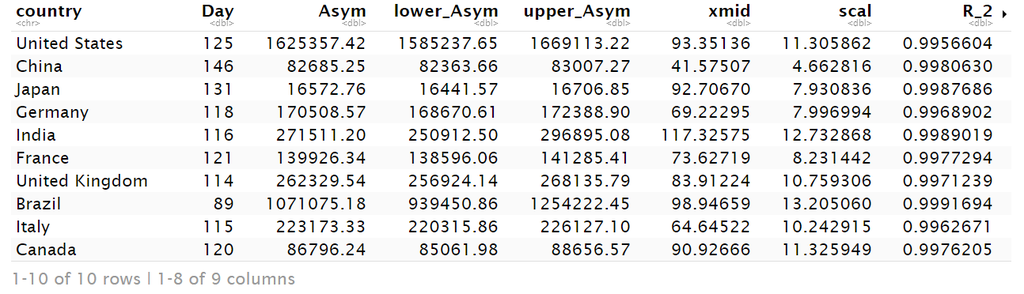

## 累计确诊病例回归拟合分析

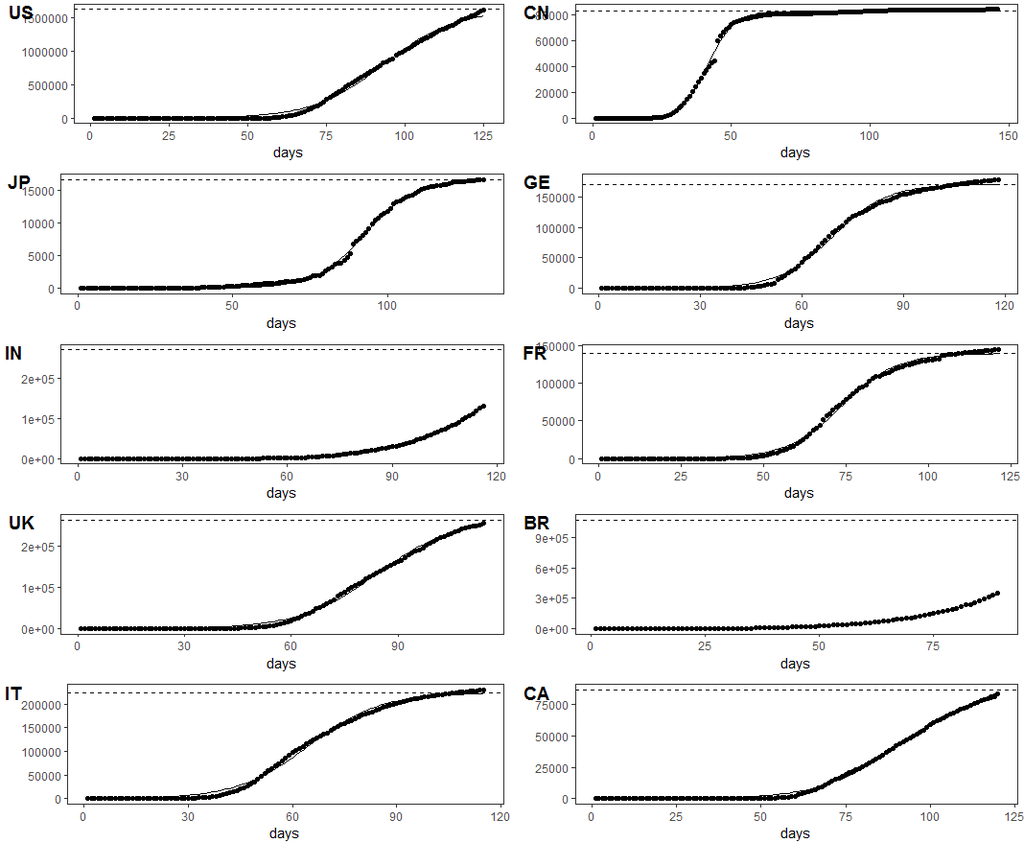

## 每日确诊增长率趋势分析

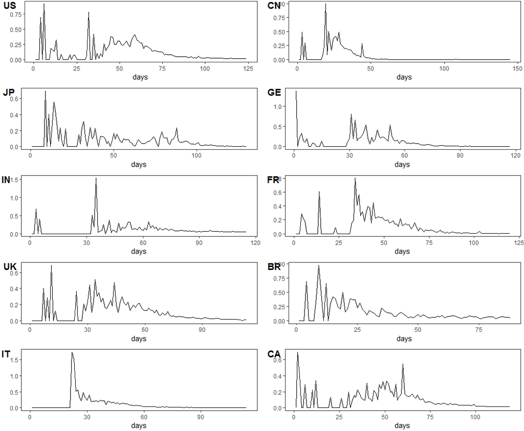